```python
import pandas as pd
import numpy as np
import matplotlib.pyplot as plt
import seaborn as sns
from sklearn.metrics import confusion_matrix as cm
from sklearn.model_selection import train_test_split
import sklearn.metrics as metrics
from sklearn.preprocessing import LabelEncoder
from sklearn.preprocessing import OneHotEncoder
from sklearn.tree import DecisionTreeClassifier, plot_tree
from sklearn.ensemble import RandomForestClassifier as rfc
from sklearn.linear_model import LogisticRegression
import statsmodels.api as sm
import statsmodels.formula.api as smf
from sklearn import model_selection as ms
from sklearn.cluster import KMeans as km
from sklearn.feature_selection import SelectKBest as skb
from sklearn.feature_selection import chi2, f_regression
from sklearn.metrics import roc_curve, roc_auc_score
import matplotlib.lines as mlines
import matplotlib.transforms as mtransforms
from sklearn.feature_selection import SelectFromModel as sfm
```

# Cleaning and processing of Covid dataset

### Previewing data

```python
#Preview of the data
covid_df = pd.read_csv('us_covid19_daily.csv')
pd.set_option('display.max_columns', None)
covid_df.head(5)
```

|  | date | states | positive | negative | pending | hospitalizedCurrently | hospitalizedCumulative | inIcuCurrently | inIcuCumulative | onVentilatorCurrently | onVentilatorCumulative | recovered | dateChecked | death | hospitalized | totalTestResults | lastModified | total | posNeg | deathIncrease | hospitalizedIncrease | negativeIncrease | positiveIncrease | totalTestResultsIncrease | hash |
| --- | --- | --- | --- | --- | --- | --- | --- | --- | --- | --- | --- | --- | --- | --- | --- | --- | --- | --- | --- | --- | --- | --- | --- | --- | --- |
| 0 | 20201206 | 56 | 14534035 | 161986294 | 13592.0 | 101487.0 | 585676.0 | 20145.0 | 31946.0 | 7094.0 | 3322.0 | 5624444.0 | 2020-12-06T24:00:00Z | 273374.0 | 585676.0 | 204063869 | 2020-12-06T24:00:00Z | 0 | 0 | 1138 | 2256 | 1172590 | 176771 | 1634532 | 9cf16504f91958e803a2197daf8c2528a4eddc18 |
| 1 | 20201205 | 56 | 14357264 | 160813704 | 13433.0 | 101190.0 | 583420.0 | 19950.0 | 31831.0 | 7005.0 | 3321.0 | 5576026.0 | 2020-12-05T24:00:00Z | 272236.0 | 583420.0 | 202429337 | 2020-12-05T24:00:00Z | 0 | 0 | 2445 | 3316 | 1526995 | 211073 | 2169756 | 6249216c5f097c94ce33a811dab011a483a42404 |
| 2 | 20201204 | 56 | 14146191 | 159286709 | 12714.0 | 101276.0 | 580104.0 | 19858.0 | 31608.0 | 6999.0 | 3305.0 | 5470389.0 | 2020-12-04T24:00:00Z | 269791.0 | 580104.0 | 200259581 | 2020-12-04T24:00:00Z | 0 | 0 | 2563 | 4652 | 1260657 | 224831 | 1854869 | ae30ea088584335ba4d57ee927f8dbda6add74db |
| 3 | 20201203 | 56 | 13921360 | 158026052 | 15106.0 | 100755.0 | 575452.0 | 19723.0 | 31276.0 | 6867.0 | 3280.0 | 5404018.0 | 2020-12-03T24:00:00Z | 267228.0 | 575452.0 | 198404712 | 2020-12-03T24:00:00Z | 0 | 0 | 2706 | 5331 | 1238465 | 210204 | 1828230 | 0f253d185ecb336cdd18a4c61996eda1b7eef13b |
| 4 | 20201202 | 56 | 13711156 | 156787587 | 14368.0 | 100322.0 | 570121.0 | 19680.0 | 31038.0 | 6855.0 | 3252.0 | 5322128.0 | 2020-12-02T24:00:00Z | 264522.0 | 570121.0 | 196576482 | 2020-12-02T24:00:00Z | 0 | 0 | 2733 | 5028 | 982032 | 195796 | 1459202 | 477c17b6302d0485195e77ecf8270a974f7a3c82 |

```python
print(covid_df.columns)
print("\nNumber of rows and columns" + str(covid_df.shape) )
#Dataset has 320 rows and 25 columns
```

```
Index(['date', 'states', 'positive', 'negative', 'pending',
       'hospitalizedCurrently', 'hospitalizedCumulative', 'inIcuCurrently',
       'inIcuCumulative', 'onVentilatorCurrently', 'onVentilatorCumulative',
       'recovered', 'dateChecked', 'death', 'hospitalized', 'totalTestResults',
       'lastModified', 'total', 'posNeg', 'deathIncrease',
       'hospitalizedIncrease', 'negativeIncrease', 'positiveIncrease',
       'totalTestResultsIncrease', 'hash'],
      dtype='object')

Number of rows and columns(320, 25)
```

### Dropping non essential columns

```python
#Removal of non essential columns (useless columns)
cols_to_drop=['states','pending','dateChecked','lastModified','total','posNeg','hash']
covid_df.drop(columns=cols_to_drop, inplace=True)
print(covid_df.columns)
print(len(covid_df.columns))
```

```
Index(['date', 'positive', 'negative', 'hospitalizedCurrently',
       'hospitalizedCumulative', 'inIcuCurrently', 'inIcuCumulative',
       'onVentilatorCurrently', 'onVentilatorCumulative', 'recovered', 'death',
       'hospitalized', 'totalTestResults', 'deathIncrease',
       'hospitalizedIncrease', 'negativeIncrease', 'positiveIncrease',
       'totalTestResultsIncrease'],
      dtype='object')
18
```

```python
#Since we are monitoring the relation between covid and increases in stock DAILY, cummulative variables will be dropped
cum_cols_drop=['hospitalizedCumulative','inIcuCumulative','onVentilatorCumulative',]
covid_df.drop(columns=cum_cols_drop, inplace=True)
print(covid_df.columns)
print(len(covid_df.columns))
```

```
Index(['date', 'positive', 'negative', 'hospitalizedCurrently',
       'inIcuCurrently', 'onVentilatorCurrently', 'recovered', 'death',
       'hospitalized', 'totalTestResults', 'deathIncrease',
       'hospitalizedIncrease', 'negativeIncrease', 'positiveIncrease',
       'totalTestResultsIncrease'],
      dtype='object')
15
```

```python
# To avoid overfitting,unrelated variables to stocks will be dropped
# Purpose: Generalize covid situation
ntrelated_cols = ['inIcuCurrently','onVentilatorCurrently']
covid_df.drop(columns=ntrelated_cols, inplace=True)
print(covid_df.columns)
print(len(covid_df.columns))
```

```
Index(['date', 'positive', 'negative', 'hospitalizedCurrently', 'recovered',
       'death', 'hospitalized', 'totalTestResults', 'deathIncrease',
       'hospitalizedIncrease', 'negativeIncrease', 'positiveIncrease',
       'totalTestResultsIncrease'],
      dtype='object')
13
```

### Inverting dataset due to reversed date order

```python
#Since the dates for the dataset is from latest to oldest, the order of the datset will be inverted
covid_df = covid_df[::-1].reset_index(drop=True)
```

```python
covid_df['date'] = pd.to_datetime(covid_df['date'], format='%Y%m%d')
```

### Dropping rows with nan values

```python
#Rows with nan values will be dropped , these columns have Nan Values , resulting from the beginning of covid cases
covid_df= covid_df.dropna().reset_index(drop=True)
```

```python
#Used for checking additional null values
covid_df.isnull().sum()
```

```
date                        0
positive                    0
negative                    0
hospitalizedCurrently       0
recovered                   0
death                       0
hospitalized                0
totalTestResults            0
deathIncrease               0
hospitalizedIncrease        0
negativeIncrease            0
positiveIncrease            0
totalTestResultsIncrease    0
dtype: int64
```

```python
covid_df.to_csv('covid_df_preprocessed.csv', index=False)
```

## Cleaning and processing S&P500 healthcare data

### Methodology

```python
# Approach of making the healthcare data as the dependant variable are as follows
# 1. non essential columns from the dataset will be dropped
# 2. only variables date, High and Low will remain in the dataset
# 3. a new variable/column called avg_price will be made by taking the average of the high and low price
# 4. create a new variable/column named stock_trend
# 4. by comparing the avg_price of current date and the previous date, if the avg_price is higher, denote stock trend with 1,
#    else denote by 0.
# 5. the value 1 in the stock trend columns shows increase in avg_stock price, 0 shows decrease in stock price
```

### Importing Healthcare stock data

```python
hc_df = pd.read_csv('SP500Data.csv')
hc_df.head(3)
```

|  | Date | Price | Open | High | Low | Vol. | Change % |
| --- | --- | --- | --- | --- | --- | --- | --- |
| 0 | Dec 09, 2020 | 1,306.48 | 1,311.95 | 1,316.01 | 1,300.26 | 240.14M | -0.29% |
| 1 | Dec 08, 2020 | 1,310.26 | 1,300.40 | 1,311.57 | 1,298.92 | 234.52M | 0.73% |
| 2 | Dec 07, 2020 | 1,300.77 | 1,308.51 | 1,308.61 | 1,296.23 | 191.66M | -0.62% |

### Inverting dataset due to reversed date order

```python
hc_df = hc_df[::-1].reset_index(drop=True)
hc_df.head(3)
```

|  | Date | Price | Open | High | Low | Vol. | Change % |
| --- | --- | --- | --- | --- | --- | --- | --- |
| 0 | Mar 24, 2020 | 937.08 | 906.88 | 938.93 | 904.89 | 348.87M | 7.59% |
| 1 | Mar 25, 2020 | 948.94 | 932.73 | 980.18 | 922.00 | 364.88M | 1.27% |
| 2 | Mar 26, 2020 | 1,015.18 | 957.61 | 1,017.92 | 956.09 | 335.96M | 6.98% |

### Converting date to datetime format

```python
hc_df['Date'] = pd.to_datetime(hc_df['Date'], format='%b %d, %Y')
hc_df.head(3)
```

|  | Date | Price | Open | High | Low | Vol. | Change % |
| --- | --- | --- | --- | --- | --- | --- | --- |
| 0 | 2020-03-24 | 937.08 | 906.88 | 938.93 | 904.89 | 348.87M | 7.59% |
| 1 | 2020-03-25 | 948.94 | 932.73 | 980.18 | 922.00 | 364.88M | 1.27% |
| 2 | 2020-03-26 | 1,015.18 | 957.61 | 1,017.92 | 956.09 | 335.96M | 6.98% |

### Checking data types for dataset

```python
hc_df.dtypes
```

```
Date        datetime64[ns]
Price               object
Open                object
High                object
Low                 object
Vol.                object
Change %            object
dtype: object
```

We need to change the high and low columns to float data type for the purpose of making a calculation later

### Changing data type and removal of non essential columns

```python
#Dropping non essential columns
hc_df.drop(columns=['Price','Open','Vol.','Change %'], inplace=True)

#Removal of the , symbol in both High and Low columns
hc_df['High'] = hc_df['High'].str.replace(",", "")
hc_df['Low'] = hc_df['Low'].str.replace(",", "")

#Converting values in High and Low columns to float
hc_df['High']=hc_df['High'].astype(float)
hc_df['Low']=hc_df['Low'].astype(float)
```

### Creating new column (avg_price)

```python
hc_df['avg_price'] = (hc_df['High'] + hc_df['Low'])/2

#High and Low column no longer needed, these columns will be dropped
hc_df.drop(columns=['High','Low'], inplace=True)
hc_df.head(11)
```

|  | Date | avg_price |
| --- | --- | --- |
| 0 | 2020-03-24 | 921.910 |
| 1 | 2020-03-25 | 951.090 |
| 2 | 2020-03-26 | 987.005 |
| 3 | 2020-03-27 | 999.825 |
| 4 | 2020-03-30 | 1023.050 |
| 5 | 2020-03-31 | 1032.920 |
| 6 | 2020-04-01 | 995.660 |
| 7 | 2020-04-02 | 1000.925 |
| 8 | 2020-04-03 | 1012.910 |
| 9 | 2020-04-06 | 1054.140 |
| 10 | 2020-04-07 | 1074.145 |

Note that the dates aren't continuous. Some dates are missing in between. Hence, we will first create a stock_trend column and denote all of them with the value 3. If the dates corresponding to the rows have a previous date ( strictly 1 day difference between the dates), compare the avg_price of the previous row and denote the trend column with either the value 1 or 0. After all processing is done, drop all rows that doesn't have a previous date ( value for stock_trend column is 3) and drop the avg_price column.

```python
hc_df['stock_trend'] = 3

#temporarily convert date format to int (so that the difference can be calculated)
hc_df['Date'] = hc_df["Date"].dt.strftime("%Y%m%d")
hc_df['Date']=hc_df['Date'].astype(int)

for i in range (1,hc_df.shape[0]):
    day_diff = hc_df.loc[i].Date - hc_df.loc[i-1].Date

    if day_diff ==1 or day_diff>=70:
        if hc_df.loc[i].avg_price > hc_df.loc[i-1].avg_price:
            hc_df['stock_trend'][i] = 1

        elif hc_df.loc[i].avg_price < hc_df.loc[i-1].avg_price:
            hc_df['stock_trend'][i] = 0
```

```python
hc_df = hc_df.loc[hc_df['stock_trend']!=3]
hc_df.drop(columns=['avg_price'], inplace=True)
```

### Reconverting date back to date time format

```python
hc_df['Date'] = pd.to_datetime(hc_df['Date'], format= '%Y%m%d')
```

```python
hc_df.to_csv('hc_df_preprocessed.csv', index=False)
```

### Aggregation of Covid and Stock data

```python
#importing stock trend data.
stockdf = pd.read_csv('hc_df_preprocessed.csv')
stockdf.head()
```

|  | Date | stock_trend |
| --- | --- | --- |
| 0 | 2020-03-25 | 1 |
| 1 | 2020-03-26 | 1 |
| 2 | 2020-03-27 | 1 |
| 3 | 2020-03-31 | 1 |
| 4 | 2020-04-01 | 0 |

```python
#importing covid cases data.
coviddf = pd.read_csv('covid_df_preprocessed.csv')
coviddf.head()
```

|  | date | positive | negative | hospitalizedCurrently | recovered | death | hospitalized | totalTestResults | deathIncrease | hospitalizedIncrease | negativeIncrease | positiveIncrease | totalTestResultsIncrease |
| --- | --- | --- | --- | --- | --- | --- | --- | --- | --- | --- | --- | --- | --- |
| 0 | 2020-03-25 | 75242 | 395632 | 5140.0 | 146.0 | 1058.0 | 7073.0 | 524577 | 238 | 1949 | 70882 | 12891 | 89096 |
| 1 | 2020-03-26 | 92976 | 482148 | 7805.0 | 97.0 | 1374.0 | 9551.0 | 632999 | 316 | 2478 | 86516 | 17734 | 108422 |
| 2 | 2020-03-27 | 112220 | 559423 | 10978.0 | 2418.0 | 1782.0 | 12123.0 | 735114 | 408 | 2572 | 77275 | 19244 | 102115 |
| 3 | 2020-03-28 | 131826 | 657185 | 12409.0 | 3145.0 | 2333.0 | 14532.0 | 835570 | 551 | 2409 | 97762 | 19606 | 100456 |
| 4 | 2020-03-29 | 151270 | 722597 | 14055.0 | 4076.0 | 2837.0 | 17326.0 | 919122 | 504 | 2794 | 65412 | 19444 | 83552 |

```python
#changing columns name so we can merge the data.
stockdf.rename(columns={"Date": "date"}, inplace=True)
```

```python
#Merging the data.
data = pd.merge(stockdf, coviddf, on='date')
```

```python
data
```

|  | date | stock_trend | positive | negative | hospitalizedCurrently | recovered | death | hospitalized | totalTestResults | deathIncrease | hospitalizedIncrease | negativeIncrease | positiveIncrease | totalTestResultsIncrease |
| --- | --- | --- | --- | --- | --- | --- | --- | --- | --- | --- | --- | --- | --- | --- |
| 0 | 2020-03-25 | 1 | 75242 | 395632 | 5140.0 | 146.0 | 1058.0 | 7073.0 | 524577 | 238 | 1949 | 70882 | 12891 | 89096 |
| 1 | 2020-03-26 | 1 | 92976 | 482148 | 7805.0 | 97.0 | 1374.0 | 9551.0 | 632999 | 316 | 2478 | 86516 | 17734 | 108422 |
| 2 | 2020-03-27 | 1 | 112220 | 559423 | 10978.0 | 2418.0 | 1782.0 | 12123.0 | 735114 | 408 | 2572 | 77275 | 19244 | 102115 |
| 3 | 2020-03-31 | 1 | 197924 | 906161 | 18155.0 | 5666.0 | 4332.0 | 23796.0 | 1150337 | 907 | 3998 | 87930 | 25184 | 114632 |
| 4 | 2020-04-01 | 0 | 224040 | 989609 | 20906.0 | 7084.0 | 5336.0 | 27930.0 | 1262834 | 1004 | 4134 | 83448 | 26116 | 112497 |
| ... | ... | ... | ... | ... | ... | ... | ... | ... | ... | ... | ... | ... | ... | ... |
| 139 | 2020-11-25 | 0 | 12581196 | 148129101 | 90041.0 | 4835956.0 | 253424.0 | 544898.0 | 184877012 | 2289 | 4568 | 1160187 | 183629 | 1720705 |
| 140 | 2020-12-01 | 1 | 13515360 | 155805555 | 98777.0 | 5226581.0 | 261789.0 | 565093.0 | 195117280 | 2473 | 5222 | 1941714 | 176753 | 2340996 |
| 141 | 2020-12-02 | 1 | 13711156 | 156787587 | 100322.0 | 5322128.0 | 264522.0 | 570121.0 | 196576482 | 2733 | 5028 | 982032 | 195796 | 1459202 |
| 142 | 2020-12-03 | 1 | 13921360 | 158026052 | 100755.0 | 5404018.0 | 267228.0 | 575452.0 | 198404712 | 2706 | 5331 | 1238465 | 210204 | 1828230 |
| 143 | 2020-12-04 | 1 | 14146191 | 159286709 | 101276.0 | 5470389.0 | 269791.0 | 580104.0 | 200259581 | 2563 | 4652 | 1260657 | 224831 | 1854869 |

144 rows × 14 columns

```python
data.to_csv('FinalData.csv', index=False)
```

### Data Visualization

```python
df = pd.read_csv('FinalData.csv')
```

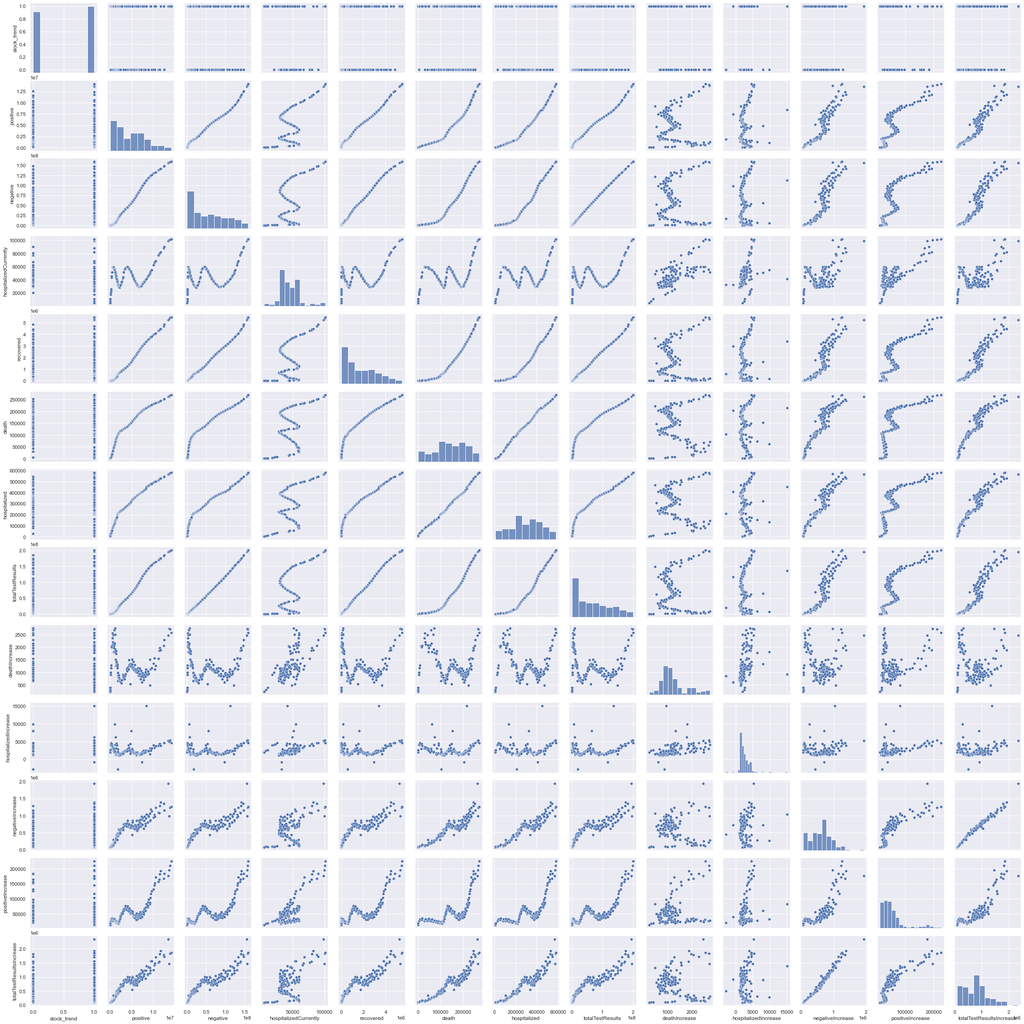

```python
sns.pairplot(df)
```

Looking at the pairplots for these variables, some variables such as negativeIncrease and totaltestResultsIncrease presents a positively linear relation. This makes sense because when there are more tests perform on each day, it is expected to have more positive / negative test results collected from the population. Some other variables presents a 'W" or "E" shaped graph, implying that the relation between the variables isn't linear. More graphs and visuallizations will be done to find out more about the data.

[output not shown]

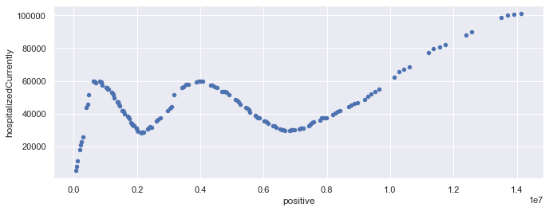

```python
df.plot(kind='scatter', x='positive', y='hospitalizedCurrently')
```

Looking at this graph, we can see that as there are more positive cases, the number of people who are being treated at the hospital does not increase linearly. This might be due to the fact that there might be more recoveries on a particular batch/clusters of people on a certain time period, people affected by the same clusters may have similar recovery time frames. But following the w shape trend of the curve, we can see that the number of people being treated in the hospital still eventually increases as time passes.

```python
#Setting date as index allow for time series plotting
df = df.set_index('date')
```

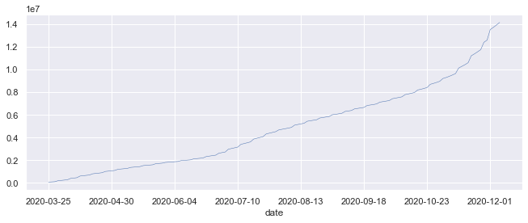

```python
#plotting positive cases against date
sns.set(rc={'figure.figsize':(11, 4)})
df['positive'].plot(linewidth=0.5);
```

As the day of the year increases, the number of cummmlative positive cases increases as well.

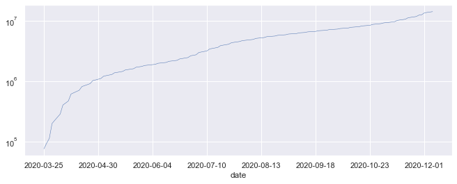

```python
#Logarithmic plotting of positive cases to show rate of increase in positive cases
df['positive'].plot(linewidth=0.5);
plt.yscale("log")
```

Using the logarithmic graph, we can see that the increases in positive cases is very rapid during march to april (high rate of increase), but the incresases in positive cases has become less rapid as time passes

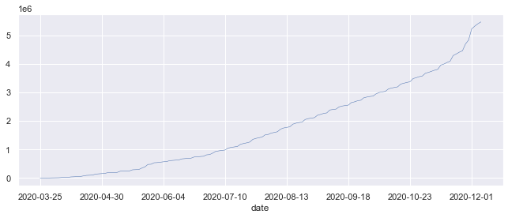

```python
df['recovered'].plot(linewidth=0.5);
```

Number of recovered people increases , following the same trend as the cummulated people who are tested positive for covid.

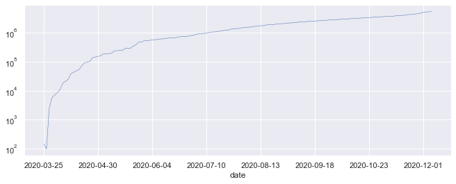

```python
#Logarithmic plotting of recovered people
df['recovered'].plot(linewidth=0.5);
plt.yscale("log")
```

Using the logarithmic graph, we can see that the rate of people recovered is relatively high (line is almost vertical) during march and april period. After the month of April, the rate of people recovered has become more consistent (rate of increase is relatively low)

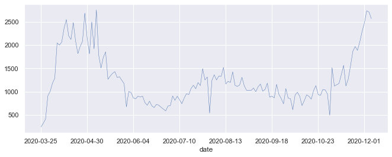

```python
df['deathIncrease'].plot(linewidth=0.5);
```

The increases in death is not very consistent, no linear or direct relationship can be found.

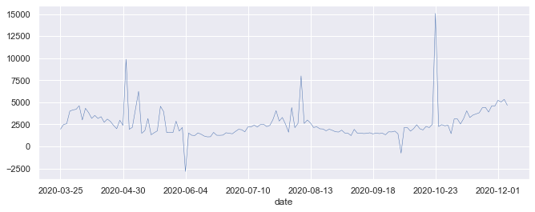

```python
df['hospitalizedIncrease'].plot(linewidth=0.5);
```

The increases in the number of people getting hospitalized is also not very consistent. One observation that could be made is that, on the month of october, there is a significant spike/increase of people that's getting hospitalized.

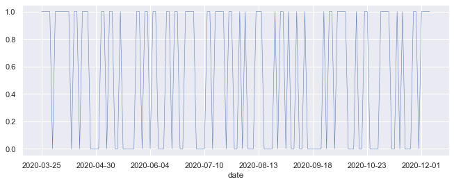

```python
df['stock_trend'].plot(linewidth=0.5);
```

Plot for stock trend does not show any obvious relationship with the dates.

# Regression Variable Selection

```python
#Importing the data.
df = pd.read_csv('FinalData.csv')
```

```python
x = df.drop(columns=['date', 'stock_trend'])
```

```python
y = df['stock_trend']
```

```python
model = sm.Logit(y, sm.add_constant(x)).fit()
model.summary()
```

```
Optimization terminated successfully.
         Current function value: 0.617014
         Iterations 6
```

Logit Regression Results

| Dep. Variable: | stock_trend | No. Observations: | 144 |
| --- | --- | --- | --- |
| Model: | Logit | Df Residuals: | 131 |
| Method: | MLE | Df Model: | 12 |
| Date: | Tue, 14 Dec 2021 | Pseudo R-squ.: | 0.1087 |
| Time: | 08:11:37 | Log-Likelihood: | -88.850 |
| converged: | True | LL-Null: | -99.688 |
| Covariance Type: | nonrobust | LLR p-value: | 0.04131 |

|  | coef | std err | z | P>\|z\| | [0.025 | 0.975] |
| --- | --- | --- | --- | --- | --- | --- |
| const | 2.4579 | 1.550 | 1.586 | 0.113 | -0.580 | 5.496 |
| positive | -2.412e-06 | 1.96e-06 | -1.234 | 0.217 | -6.24e-06 | 1.42e-06 |
| negative | 1.684e-07 | 2.88e-07 | 0.584 | 0.559 | -3.97e-07 | 7.34e-07 |
| hospitalizedCurrently | 9.338e-05 | 4.67e-05 | 1.998 | 0.046 | 1.76e-06 | 0.000 |
| recovered | 1.37e-05 | 6.31e-06 | 2.172 | 0.030 | 1.34e-06 | 2.61e-05 |
| death | -7.857e-05 | 6.74e-05 | -1.166 | 0.244 | -0.000 | 5.35e-05 |
| hospitalized | 1.693e-05 | 3.84e-05 | 0.441 | 0.659 | -5.83e-05 | 9.22e-05 |
| totalTestResults | -3.059e-07 | 2.75e-07 | -1.112 | 0.266 | -8.45e-07 | 2.33e-07 |
| deathIncrease | -0.0017 | 0.001 | -1.898 | 0.058 | -0.004 | 5.67e-05 |
| hospitalizedIncrease | -1.261e-05 | 0.000 | -0.106 | 0.915 | -0.000 | 0.000 |
| negativeIncrease | 6.192e-06 | 5.77e-06 | 1.072 | 0.284 | -5.13e-06 | 1.75e-05 |
| positiveIncrease | -1.533e-05 | 2.38e-05 | -0.644 | 0.520 | -6.2e-05 | 3.13e-05 |
| totalTestResultsIncrease | -2.551e-06 | 5.19e-06 | -0.492 | 0.623 | -1.27e-05 | 7.61e-06 |

'hospitalizedIncrease' has the largest p-value

```python
x0 = x.drop(columns = ['hospitalizedIncrease'])
```

```python
model0 = sm.Logit(y, sm.add_constant(x0)).fit()
model0.summary()
```

```
Optimization terminated successfully.
         Current function value: 0.617053
         Iterations 6
```

Logit Regression Results

| Dep. Variable: | stock_trend | No. Observations: | 144 |
| --- | --- | --- | --- |
| Model: | Logit | Df Residuals: | 132 |
| Method: | MLE | Df Model: | 11 |
| Date: | Tue, 14 Dec 2021 | Pseudo R-squ.: | 0.1087 |
| Time: | 08:11:37 | Log-Likelihood: | -88.856 |
| converged: | True | LL-Null: | -99.688 |
| Covariance Type: | nonrobust | LLR p-value: | 0.02710 |

|  | coef | std err | z | P>\|z\| | [0.025 | 0.975] |
| --- | --- | --- | --- | --- | --- | --- |
| const | 2.4382 | 1.540 | 1.583 | 0.113 | -0.581 | 5.457 |
| positive | -2.418e-06 | 1.95e-06 | -1.238 | 0.216 | -6.25e-06 | 1.41e-06 |
| negative | 1.697e-07 | 2.88e-07 | 0.589 | 0.556 | -3.95e-07 | 7.34e-07 |
| hospitalizedCurrently | 9.358e-05 | 4.67e-05 | 2.004 | 0.045 | 2.04e-06 | 0.000 |
| recovered | 1.378e-05 | 6.27e-06 | 2.197 | 0.028 | 1.49e-06 | 2.61e-05 |
| death | -7.715e-05 | 6.6e-05 | -1.168 | 0.243 | -0.000 | 5.23e-05 |
| hospitalized | 1.63e-05 | 3.79e-05 | 0.430 | 0.667 | -5.81e-05 | 9.07e-05 |
| totalTestResults | -3.086e-07 | 2.74e-07 | -1.127 | 0.260 | -8.45e-07 | 2.28e-07 |
| deathIncrease | -0.0017 | 0.001 | -1.924 | 0.054 | -0.004 | 3.27e-05 |
| negativeIncrease | 6.182e-06 | 5.77e-06 | 1.071 | 0.284 | -5.13e-06 | 1.75e-05 |
| positiveIncrease | -1.53e-05 | 2.38e-05 | -0.643 | 0.520 | -6.19e-05 | 3.13e-05 |
| totalTestResultsIncrease | -2.566e-06 | 5.18e-06 | -0.495 | 0.621 | -1.27e-05 | 7.6e-06 |

'hospitalized' have the largest p-value.

```python
x1 = x0.drop(columns = ['hospitalized'])
```

```python
model1 = sm.Logit(y, sm.add_constant(x1)).fit()
model1.summary()
```

```
Optimization terminated successfully.
         Current function value: 0.617695
         Iterations 6
```

Logit Regression Results

| Dep. Variable: | stock_trend | No. Observations: | 144 |
| --- | --- | --- | --- |
| Model: | Logit | Df Residuals: | 133 |
| Method: | MLE | Df Model: | 10 |
| Date: | Tue, 14 Dec 2021 | Pseudo R-squ.: | 0.1077 |
| Time: | 08:11:37 | Log-Likelihood: | -88.948 |
| converged: | True | LL-Null: | -99.688 |
| Covariance Type: | nonrobust | LLR p-value: | 0.01798 |

|  | coef | std err | z | P>\|z\| | [0.025 | 0.975] |
| --- | --- | --- | --- | --- | --- | --- |
| const | 2.6480 | 1.491 | 1.776 | 0.076 | -0.275 | 5.571 |
| positive | -2.245e-06 | 1.91e-06 | -1.174 | 0.240 | -5.99e-06 | 1.5e-06 |
| negative | 1.983e-07 | 2.79e-07 | 0.712 | 0.477 | -3.48e-07 | 7.44e-07 |
| hospitalizedCurrently | 9.529e-05 | 4.65e-05 | 2.048 | 0.041 | 4.08e-06 | 0.000 |
| recovered | 1.378e-05 | 6.31e-06 | 2.185 | 0.029 | 1.42e-06 | 2.61e-05 |
| death | -5.033e-05 | 2.12e-05 | -2.370 | 0.018 | -9.19e-05 | -8.71e-06 |
| totalTestResults | -3.345e-07 | 2.67e-07 | -1.254 | 0.210 | -8.57e-07 | 1.88e-07 |
| deathIncrease | -0.0017 | 0.001 | -1.928 | 0.054 | -0.004 | 2.93e-05 |
| negativeIncrease | 6.391e-06 | 5.76e-06 | 1.109 | 0.267 | -4.9e-06 | 1.77e-05 |
| positiveIncrease | -1.368e-05 | 2.35e-05 | -0.583 | 0.560 | -5.97e-05 | 3.23e-05 |
| totalTestResultsIncrease | -2.826e-06 | 5.16e-06 | -0.547 | 0.584 | -1.29e-05 | 7.29e-06 |

'totalTestResultsIncrease' have the largest p-value.

```python
x2 = x1.drop(columns = ['totalTestResultsIncrease'])
```

```python
model2 = sm.Logit(y, sm.add_constant(x2)).fit()
model2.summary()
```

```
Optimization terminated successfully.
         Current function value: 0.618763
         Iterations 6
```

Logit Regression Results

| Dep. Variable: | stock_trend | No. Observations: | 144 |
| --- | --- | --- | --- |
| Model: | Logit | Df Residuals: | 134 |
| Method: | MLE | Df Model: | 9 |
| Date: | Tue, 14 Dec 2021 | Pseudo R-squ.: | 0.1062 |
| Time: | 08:11:37 | Log-Likelihood: | -89.102 |
| converged: | True | LL-Null: | -99.688 |
| Covariance Type: | nonrobust | LLR p-value: | 0.01191 |

|  | coef | std err | z | P>\|z\| | [0.025 | 0.975] |
| --- | --- | --- | --- | --- | --- | --- |
| const | 2.7028 | 1.490 | 1.814 | 0.070 | -0.218 | 5.624 |
| positive | -2.161e-06 | 1.9e-06 | -1.137 | 0.255 | -5.88e-06 | 1.56e-06 |
| negative | 1.939e-07 | 2.77e-07 | 0.700 | 0.484 | -3.49e-07 | 7.37e-07 |
| hospitalizedCurrently | 9.907e-05 | 4.6e-05 | 2.155 | 0.031 | 8.98e-06 | 0.000 |
| recovered | 1.371e-05 | 6.28e-06 | 2.184 | 0.029 | 1.41e-06 | 2.6e-05 |
| death | -5.141e-05 | 2.11e-05 | -2.434 | 0.015 | -9.28e-05 | -1e-05 |
| totalTestResults | -3.366e-07 | 2.65e-07 | -1.268 | 0.205 | -8.57e-07 | 1.84e-07 |
| deathIncrease | -0.0018 | 0.001 | -2.057 | 0.040 | -0.004 | -8.63e-05 |
| negativeIncrease | 3.571e-06 | 2.45e-06 | 1.456 | 0.145 | -1.24e-06 | 8.38e-06 |
| positiveIncrease | -1.925e-05 | 2.12e-05 | -0.910 | 0.363 | -6.07e-05 | 2.22e-05 |

'negative' have the largest p-value.

```python
x3 = x2.drop(columns = ['negative'])
```

```python
model3 = sm.Logit(y, sm.add_constant(x3)).fit()
model3.summary()
```

```
Optimization terminated successfully.
         Current function value: 0.620480
         Iterations 6
```

Logit Regression Results

| Dep. Variable: | stock_trend | No. Observations: | 144 |
| --- | --- | --- | --- |
| Model: | Logit | Df Residuals: | 135 |
| Method: | MLE | Df Model: | 8 |
| Date: | Tue, 14 Dec 2021 | Pseudo R-squ.: | 0.1037 |
| Time: | 08:11:37 | Log-Likelihood: | -89.349 |
| converged: | True | LL-Null: | -99.688 |
| Covariance Type: | nonrobust | LLR p-value: | 0.008053 |

|  | coef | std err | z | P>\|z\| | [0.025 | 0.975] |
| --- | --- | --- | --- | --- | --- | --- |
| const | 2.9562 | 1.469 | 2.012 | 0.044 | 0.076 | 5.836 |
| positive | -1.429e-06 | 1.59e-06 | -0.900 | 0.368 | -4.54e-06 | 1.68e-06 |
| hospitalizedCurrently | 9.288e-05 | 4.5e-05 | 2.066 | 0.039 | 4.75e-06 | 0.000 |
| recovered | 1.138e-05 | 5.24e-06 | 2.171 | 0.030 | 1.11e-06 | 2.17e-05 |
| death | -5.131e-05 | 2.14e-05 | -2.394 | 0.017 | -9.33e-05 | -9.31e-06 |
| totalTestResults | -1.607e-07 | 8.11e-08 | -1.982 | 0.047 | -3.2e-07 | -1.81e-09 |
| deathIncrease | -0.0020 | 0.001 | -2.261 | 0.024 | -0.004 | -0.000 |
| negativeIncrease | 3.874e-06 | 2.45e-06 | 1.582 | 0.114 | -9.25e-07 | 8.67e-06 |
| positiveIncrease | -2.682e-05 | 1.85e-05 | -1.446 | 0.148 | -6.32e-05 | 9.53e-06 |

'positive' have the largest p-value.

```python
x4 = x3.drop(columns = ['positive'])
```

```python
model4 = sm.Logit(y, sm.add_constant(x4)).fit()
model4.summary()
```

```
Optimization terminated successfully.
         Current function value: 0.623275
         Iterations 6
```

Logit Regression Results

| Dep. Variable: | stock_trend | No. Observations: | 144 |
| --- | --- | --- | --- |
| Model: | Logit | Df Residuals: | 136 |
| Method: | MLE | Df Model: | 7 |
| Date: | Tue, 14 Dec 2021 | Pseudo R-squ.: | 0.09968 |
| Time: | 08:11:38 | Log-Likelihood: | -89.752 |
| converged: | True | LL-Null: | -99.688 |
| Covariance Type: | nonrobust | LLR p-value: | 0.005850 |

|  | coef | std err | z | P>\|z\| | [0.025 | 0.975] |
| --- | --- | --- | --- | --- | --- | --- |
| const | 3.5882 | 1.476 | 2.432 | 0.015 | 0.696 | 6.480 |
| hospitalizedCurrently | 7.422e-05 | 4e-05 | 1.855 | 0.064 | -4.18e-06 | 0.000 |
| recovered | 7.846e-06 | 3.3e-06 | 2.378 | 0.017 | 1.38e-06 | 1.43e-05 |
| death | -6.19e-05 | 1.9e-05 | -3.256 | 0.001 | -9.92e-05 | -2.46e-05 |
| totalTestResults | -1.419e-07 | 7.58e-08 | -1.872 | 0.061 | -2.91e-07 | 6.7e-09 |
| deathIncrease | -0.0020 | 0.001 | -2.278 | 0.023 | -0.004 | -0.000 |
| negativeIncrease | 3.599e-06 | 2.41e-06 | 1.495 | 0.135 | -1.12e-06 | 8.32e-06 |
| positiveIncrease | -2.81e-05 | 1.85e-05 | -1.521 | 0.128 | -6.43e-05 | 8.11e-06 |

```python
x5 = x4.drop(columns = ['negativeIncrease'])
```

```python
model5 = sm.Logit(y, sm.add_constant(x5)).fit()
model5.summary()
```

```
Optimization terminated successfully.
         Current function value: 0.631667
         Iterations 6
```

Logit Regression Results

| Dep. Variable: | stock_trend | No. Observations: | 144 |
| --- | --- | --- | --- |
| Model: | Logit | Df Residuals: | 137 |
| Method: | MLE | Df Model: | 6 |
| Date: | Tue, 14 Dec 2021 | Pseudo R-squ.: | 0.08755 |
| Time: | 08:11:38 | Log-Likelihood: | -90.960 |
| converged: | True | LL-Null: | -99.688 |
| Covariance Type: | nonrobust | LLR p-value: | 0.007745 |

|  | coef | std err | z | P>\|z\| | [0.025 | 0.975] |
| --- | --- | --- | --- | --- | --- | --- |
| const | 3.6818 | 1.455 | 2.530 | 0.011 | 0.830 | 6.534 |
| hospitalizedCurrently | 7.52e-05 | 3.91e-05 | 1.924 | 0.054 | -1.39e-06 | 0.000 |
| recovered | 7.003e-06 | 3.19e-06 | 2.199 | 0.028 | 7.6e-07 | 1.32e-05 |
| death | -4.612e-05 | 1.5e-05 | -3.065 | 0.002 | -7.56e-05 | -1.66e-05 |
| totalTestResults | -1.285e-07 | 7.45e-08 | -1.725 | 0.084 | -2.75e-07 | 1.75e-08 |
| deathIncrease | -0.0023 | 0.001 | -2.632 | 0.008 | -0.004 | -0.001 |
| positiveIncrease | -1.552e-05 | 1.58e-05 | -0.980 | 0.327 | -4.66e-05 | 1.55e-05 |

'positiveIncrease' have the largest p-value.

```python
x6 = x5.drop(columns = ['positiveIncrease'])
```

```python
model6 = sm.Logit(y, sm.add_constant(x6)).fit()
model6.summary()
```

```
Optimization terminated successfully.
         Current function value: 0.635060
         Iterations 6
```

Logit Regression Results

| Dep. Variable: | stock_trend | No. Observations: | 144 |
| --- | --- | --- | --- |
| Model: | Logit | Df Residuals: | 138 |
| Method: | MLE | Df Model: | 5 |
| Date: | Tue, 14 Dec 2021 | Pseudo R-squ.: | 0.08265 |
| Time: | 08:11:38 | Log-Likelihood: | -91.449 |
| converged: | True | LL-Null: | -99.688 |
| Covariance Type: | nonrobust | LLR p-value: | 0.005602 |

|  | coef | std err | z | P>\|z\| | [0.025 | 0.975] |
| --- | --- | --- | --- | --- | --- | --- |
| const | 3.6840 | 1.515 | 2.432 | 0.015 | 0.716 | 6.652 |
| hospitalizedCurrently | 4.286e-05 | 1.99e-05 | 2.150 | 0.032 | 3.8e-06 | 8.19e-05 |
| recovered | 6.108e-06 | 3.03e-06 | 2.017 | 0.044 | 1.73e-07 | 1.2e-05 |
| death | -4.016e-05 | 1.41e-05 | -2.854 | 0.004 | -6.77e-05 | -1.26e-05 |
| totalTestResults | -1.182e-07 | 7.33e-08 | -1.614 | 0.107 | -2.62e-07 | 2.53e-08 |
| deathIncrease | -0.0018 | 0.001 | -2.599 | 0.009 | -0.003 | -0.000 |

'totalTestResults' have the largest p-value.

```python
x7 = x6.drop(columns = ['totalTestResults'])
```

```python
model7 = sm.Logit(y, sm.add_constant(x7)).fit()
model7.summary()
```

```
Optimization terminated successfully.
         Current function value: 0.645477
         Iterations 6
```

Logit Regression Results

| Dep. Variable: | stock_trend | No. Observations: | 144 |
| --- | --- | --- | --- |
| Model: | Logit | Df Residuals: | 139 |
| Method: | MLE | Df Model: | 4 |
| Date: | Tue, 14 Dec 2021 | Pseudo R-squ.: | 0.06761 |
| Time: | 08:11:38 | Log-Likelihood: | -92.949 |
| converged: | True | LL-Null: | -99.688 |
| Covariance Type: | nonrobust | LLR p-value: | 0.009158 |

|  | coef | std err | z | P>\|z\| | [0.025 | 0.975] |
| --- | --- | --- | --- | --- | --- | --- |
| const | 3.0733 | 1.367 | 2.248 | 0.025 | 0.394 | 5.752 |
| hospitalizedCurrently | 3.448e-05 | 1.87e-05 | 1.840 | 0.066 | -2.25e-06 | 7.12e-05 |
| recovered | 1.357e-06 | 5.63e-07 | 2.412 | 0.016 | 2.55e-07 | 2.46e-06 |
| death | -3.618e-05 | 1.3e-05 | -2.783 | 0.005 | -6.17e-05 | -1.07e-05 |
| deathIncrease | -0.0014 | 0.001 | -2.225 | 0.026 | -0.003 | -0.000 |

'hospitalizedCurrently' have the largest p-value.

```python
x8 = x7.drop(columns = ['hospitalizedCurrently'])
```

```python
model8 = sm.Logit(y, sm.add_constant(x8)).fit()
model8.summary()
```

```
Optimization terminated successfully.
         Current function value: 0.657678
         Iterations 6
```

Logit Regression Results

| Dep. Variable: | stock_trend | No. Observations: | 144 |
| --- | --- | --- | --- |
| Model: | Logit | Df Residuals: | 140 |
| Method: | MLE | Df Model: | 3 |
| Date: | Tue, 14 Dec 2021 | Pseudo R-squ.: | 0.04998 |
| Time: | 08:11:38 | Log-Likelihood: | -94.706 |
| converged: | True | LL-Null: | -99.688 |
| Covariance Type: | nonrobust | LLR p-value: | 0.01887 |

|  | coef | std err | z | P>\|z\| | [0.025 | 0.975] |
| --- | --- | --- | --- | --- | --- | --- |
| const | 3.2092 | 1.418 | 2.263 | 0.024 | 0.430 | 5.988 |
| recovered | 1.399e-06 | 5.8e-07 | 2.414 | 0.016 | 2.63e-07 | 2.54e-06 |
| death | -3.357e-05 | 1.34e-05 | -2.505 | 0.012 | -5.98e-05 | -7.3e-06 |
| deathIncrease | -0.0006 | 0.000 | -1.340 | 0.180 | -0.001 | 0.000 |

'deathIncrease' have the largest p-value.

```python
x9 = x8.drop(columns = ['deathIncrease'])
```

```python
model9 = sm.Logit(y, sm.add_constant(x9)).fit()
model9.summary()
```

```
Optimization terminated successfully.
         Current function value: 0.664562
         Iterations 5
```

Logit Regression Results

| Dep. Variable: | stock_trend | No. Observations: | 144 |
| --- | --- | --- | --- |
| Model: | Logit | Df Residuals: | 141 |
| Method: | MLE | Df Model: | 2 |
| Date: | Tue, 14 Dec 2021 | Pseudo R-squ.: | 0.04004 |
| Time: | 08:11:38 | Log-Likelihood: | -95.697 |
| converged: | True | LL-Null: | -99.688 |
| Covariance Type: | nonrobust | LLR p-value: | 0.01848 |

|  | coef | std err | z | P>\|z\| | [0.025 | 0.975] |
| --- | --- | --- | --- | --- | --- | --- |
| const | 1.7481 | 0.687 | 2.544 | 0.011 | 0.401 | 3.095 |
| recovered | 9.46e-07 | 4.05e-07 | 2.338 | 0.019 | 1.53e-07 | 1.74e-06 |
| death | -2.309e-05 | 9.01e-06 | -2.564 | 0.010 | -4.07e-05 | -5.44e-06 |

Since all the remaining variable all have a p-value of smaller than 0.05, no more variable will need to be removed.

Based on the variable selection method, 'recovered' and 'death' are the suitable variables for the regression model.

# Regression Modeling

```python
selected_columns = ['recovered', 'death']
x = df[selected_columns]
```

```python
# Assign 'stock_trend' as dependent variable
y = df['stock_trend']
```

```python
model = sm.Logit(y, sm.add_constant(x)).fit()
model.summary()
```

```
Optimization terminated successfully.
         Current function value: 0.664562
         Iterations 5
```

Logit Regression Results

| Dep. Variable: | stock_trend | No. Observations: | 144 |
| --- | --- | --- | --- |
| Model: | Logit | Df Residuals: | 141 |
| Method: | MLE | Df Model: | 2 |
| Date: | Tue, 14 Dec 2021 | Pseudo R-squ.: | 0.04004 |
| Time: | 08:11:38 | Log-Likelihood: | -95.697 |
| converged: | True | LL-Null: | -99.688 |
| Covariance Type: | nonrobust | LLR p-value: | 0.01848 |

|  | coef | std err | z | P>\|z\| | [0.025 | 0.975] |
| --- | --- | --- | --- | --- | --- | --- |
| const | 1.7481 | 0.687 | 2.544 | 0.011 | 0.401 | 3.095 |
| recovered | 9.46e-07 | 4.05e-07 | 2.338 | 0.019 | 1.53e-07 | 1.74e-06 |
| death | -2.309e-05 | 9.01e-06 | -2.564 | 0.010 | -4.07e-05 | -5.44e-06 |

```python
#Spliting the training and the testing data.
xtrain0, xtest0, ytrain0, ytest0 = ms.train_test_split(x, y, test_size=0.25, random_state=2)
```

```python
model0 = sm.Logit(ytrain0, sm.add_constant(xtrain0)).fit()
model0.summary()
```

```
Optimization terminated successfully.
         Current function value: 0.668945
         Iterations 5
```

Logit Regression Results

| Dep. Variable: | stock_trend | No. Observations: | 108 |
| --- | --- | --- | --- |
| Model: | Logit | Df Residuals: | 105 |
| Method: | MLE | Df Model: | 2 |
| Date: | Tue, 14 Dec 2021 | Pseudo R-squ.: | 0.03492 |
| Time: | 08:11:38 | Log-Likelihood: | -72.246 |
| converged: | True | LL-Null: | -74.860 |
| Covariance Type: | nonrobust | LLR p-value: | 0.07325 |

|  | coef | std err | z | P>\|z\| | [0.025 | 0.975] |
| --- | --- | --- | --- | --- | --- | --- |
| const | 1.5170 | 0.769 | 1.973 | 0.049 | 0.010 | 3.024 |
| recovered | 9.058e-07 | 4.49e-07 | 2.016 | 0.044 | 2.5e-08 | 1.79e-06 |
| death | -2.158e-05 | 1.01e-05 | -2.147 | 0.032 | -4.13e-05 | -1.88e-06 |

```python
trainpred0 = model.predict(sm.add_constant(xtrain0)).round(decimals=0)
print("Accuracy:",metrics.accuracy_score(ytrain0, trainpred0))
```

```
Accuracy: 0.5648148148148148
```

```python
testpred0 = model.predict(sm.add_constant(xtest0)).round(decimals=0)
print("Accuracy:",metrics.accuracy_score(ytest0, testpred0))
```

```
Accuracy: 0.5555555555555556
```

```python
xtrain1, xtest1, ytrain1, ytest1 = ms.train_test_split(x, y, test_size=0.2, random_state=1)
```

The second model is with 80% train size and 20% test size.

```python
model1 = sm.Logit(ytrain1, sm.add_constant(xtrain1)).fit()
model1.summary()
```

```
Optimization terminated successfully.
         Current function value: 0.658717
         Iterations 5
```

Logit Regression Results

| Dep. Variable: | stock_trend | No. Observations: | 115 |
| --- | --- | --- | --- |
| Model: | Logit | Df Residuals: | 112 |
| Method: | MLE | Df Model: | 2 |
| Date: | Tue, 14 Dec 2021 | Pseudo R-squ.: | 0.04545 |
| Time: | 08:11:38 | Log-Likelihood: | -75.752 |
| converged: | True | LL-Null: | -79.359 |
| Covariance Type: | nonrobust | LLR p-value: | 0.02713 |

|  | coef | std err | z | P>\|z\| | [0.025 | 0.975] |
| --- | --- | --- | --- | --- | --- | --- |
| const | 1.9142 | 0.776 | 2.465 | 0.014 | 0.392 | 3.436 |
| recovered | 8.012e-07 | 4.45e-07 | 1.802 | 0.072 | -7.04e-08 | 1.67e-06 |
| death | -2.199e-05 | 1e-05 | -2.190 | 0.029 | -4.17e-05 | -2.31e-06 |

```python
trainpred1 = model1.predict(sm.add_constant(xtrain1)).round(decimals=0)
print("Accuracy:",metrics.accuracy_score(ytrain1, trainpred1))
```

```
Accuracy: 0.5478260869565217
```

```python
testpred1 = model1.predict(sm.add_constant(xtest1)).round(decimals=0)
print("Accuracy:",metrics.accuracy_score(ytest1, testpred1))
```

```
Accuracy: 0.4827586206896552
```

```python
xtrain2, xtest2, ytrain2, ytest2 = ms.train_test_split(x, y, test_size=0.3, random_state=1)
```

```python
model2 = sm.Logit(ytrain2, sm.add_constant(xtrain2)).fit()
model2.summary()
```

```
Optimization terminated successfully.
         Current function value: 0.633133
         Iterations 6
```

Logit Regression Results

| Dep. Variable: | stock_trend | No. Observations: | 100 |
| --- | --- | --- | --- |
| Model: | Logit | Df Residuals: | 97 |
| Method: | MLE | Df Model: | 2 |
| Date: | Tue, 14 Dec 2021 | Pseudo R-squ.: | 0.08553 |
| Time: | 08:11:38 | Log-Likelihood: | -63.313 |
| converged: | True | LL-Null: | -69.235 |
| Covariance Type: | nonrobust | LLR p-value: | 0.002682 |

|  | coef | std err | z | P>\|z\| | [0.025 | 0.975] |
| --- | --- | --- | --- | --- | --- | --- |
| const | 2.7397 | 1.007 | 2.720 | 0.007 | 0.766 | 4.714 |
| recovered | 1.208e-06 | 5.23e-07 | 2.312 | 0.021 | 1.84e-07 | 2.23e-06 |
| death | -3.304e-05 | 1.24e-05 | -2.657 | 0.008 | -5.74e-05 | -8.67e-06 |

```python
trainpred2 = model2.predict(sm.add_constant(xtrain2)).round(decimals=0)
print("Accuracy:",metrics.accuracy_score(ytrain2, trainpred2))
```

```
Accuracy: 0.58
```

```python
testpred2 = model2.predict(sm.add_constant(xtest2)).round(decimals=0)
print("Accuracy:",metrics.accuracy_score(ytest2, testpred2))
```

```
Accuracy: 0.5
```

Repeat process with different train-test split.

```python
xtrain3, xtest3, ytrain3, ytest3 = ms.train_test_split(x, y, test_size=0.35, random_state=1)
```

The fourth model is with 65% train size and 35% test size.

```python
model3 = sm.Logit(ytrain3, sm.add_constant(xtrain3)).fit()
model3.summary()
```

```
Optimization terminated successfully.
         Current function value: 0.632527
         Iterations 6
```

Logit Regression Results

| Dep. Variable: | stock_trend | No. Observations: | 93 |
| --- | --- | --- | --- |
| Model: | Logit | Df Residuals: | 90 |
| Method: | MLE | Df Model: | 2 |
| Date: | Tue, 14 Dec 2021 | Pseudo R-squ.: | 0.08124 |
| Time: | 08:11:38 | Log-Likelihood: | -58.825 |
| converged: | True | LL-Null: | -64.027 |
| Covariance Type: | nonrobust | LLR p-value: | 0.005508 |

|  | coef | std err | z | P>\|z\| | [0.025 | 0.975] |
| --- | --- | --- | --- | --- | --- | --- |
| const | 2.7027 | 1.005 | 2.690 | 0.007 | 0.734 | 4.672 |
| recovered | 1.274e-06 | 5.37e-07 | 2.371 | 0.018 | 2.21e-07 | 2.33e-06 |
| death | -3.3e-05 | 1.26e-05 | -2.620 | 0.009 | -5.77e-05 | -8.32e-06 |

```python
trainpred3 = model3.predict(sm.add_constant(xtrain3)).round(decimals=0)
print("Accuracy:",metrics.accuracy_score(ytrain3, trainpred3))
```

```
Accuracy: 0.5591397849462365
```

```python
testpred3 = model3.predict(sm.add_constant(xtest3)).round(decimals=0)
print("Accuracy:",metrics.accuracy_score(ytest3, testpred3))
```

```
Accuracy: 0.5686274509803921
```

Repeat process with different train-test split.

```python
xtrain4, xtest4, ytrain4, ytest4 = ms.train_test_split(x, y, test_size=0.4, random_state=1)
```

The fifth model is with 60% train size and 40% test size.

```python
model4 = sm.Logit(ytrain4, sm.add_constant(xtrain4)).fit()
model4.summary()
```

```
Optimization terminated successfully.
         Current function value: 0.629278
         Iterations 6
```

Logit Regression Results

| Dep. Variable: | stock_trend | No. Observations: | 86 |
| --- | --- | --- | --- |
| Model: | Logit | Df Residuals: | 83 |
| Method: | MLE | Df Model: | 2 |
| Date: | Tue, 14 Dec 2021 | Pseudo R-squ.: | 0.08318 |
| Time: | 08:11:38 | Log-Likelihood: | -54.118 |
| converged: | True | LL-Null: | -59.028 |
| Covariance Type: | nonrobust | LLR p-value: | 0.007372 |

|  | coef | std err | z | P>\|z\| | [0.025 | 0.975] |
| --- | --- | --- | --- | --- | --- | --- |
| const | 3.1420 | 1.242 | 2.529 | 0.011 | 0.707 | 5.577 |
| recovered | 1.344e-06 | 6.15e-07 | 2.185 | 0.029 | 1.38e-07 | 2.55e-06 |
| death | -3.621e-05 | 1.5e-05 | -2.407 | 0.016 | -6.57e-05 | -6.73e-06 |

```python
trainpred4 = model4.predict(sm.add_constant(xtrain4)).round(decimals=0)
print("Accuracy:",metrics.accuracy_score(ytrain4, trainpred4))
```

```
Accuracy: 0.5348837209302325
```

```python
testpred4 = model4.predict(sm.add_constant(xtest4)).round(decimals=0)
print("Accuracy:",metrics.accuracy_score(ytest4, testpred4))
```

```
Accuracy: 0.5344827586206896
```

Based on the accuracy score on the test data, the fourth model, which is model3 with 65% train data and 35% test data is the best regression model however the testing accuracy rate is about 57% means that the model is not doing a good job predicting stock trend.

Lets create the confusion matrix for model 3 of training and testing data.

```python
testMatrix = cm(trainpred3, ytrain3)
testMatrix
```

```
array([[27, 26],
       [15, 25]], dtype=int64)
```

```python
trainMatrix = cm(testpred3, ytest3)
trainMatrix
```

```
array([[19, 14],
       [ 8, 10]], dtype=int64)
```

In both the training and testing confusion matrix we can see that the prediction of stock trend based on the covid data is very inaccurate this indicate that covid-data might not have a significant relation to the stock trend of the healthcare sector.

# Random Forest Modeling

```python
df
```

|  | date | stock_trend | positive | negative | hospitalizedCurrently | recovered | death | hospitalized | totalTestResults | deathIncrease | hospitalizedIncrease | negativeIncrease | positiveIncrease | totalTestResultsIncrease |
| --- | --- | --- | --- | --- | --- | --- | --- | --- | --- | --- | --- | --- | --- | --- |
| 0 | 2020-03-25 | 1 | 75242 | 395632 | 5140.0 | 146.0 | 1058.0 | 7073.0 | 524577 | 238 | 1949 | 70882 | 12891 | 89096 |
| 1 | 2020-03-26 | 1 | 92976 | 482148 | 7805.0 | 97.0 | 1374.0 | 9551.0 | 632999 | 316 | 2478 | 86516 | 17734 | 108422 |
| 2 | 2020-03-27 | 1 | 112220 | 559423 | 10978.0 | 2418.0 | 1782.0 | 12123.0 | 735114 | 408 | 2572 | 77275 | 19244 | 102115 |
| 3 | 2020-03-31 | 1 | 197924 | 906161 | 18155.0 | 5666.0 | 4332.0 | 23796.0 | 1150337 | 907 | 3998 | 87930 | 25184 | 114632 |
| 4 | 2020-04-01 | 0 | 224040 | 989609 | 20906.0 | 7084.0 | 5336.0 | 27930.0 | 1262834 | 1004 | 4134 | 83448 | 26116 | 112497 |
| ... | ... | ... | ... | ... | ... | ... | ... | ... | ... | ... | ... | ... | ... | ... |
| 139 | 2020-11-25 | 0 | 12581196 | 148129101 | 90041.0 | 4835956.0 | 253424.0 | 544898.0 | 184877012 | 2289 | 4568 | 1160187 | 183629 | 1720705 |
| 140 | 2020-12-01 | 1 | 13515360 | 155805555 | 98777.0 | 5226581.0 | 261789.0 | 565093.0 | 195117280 | 2473 | 5222 | 1941714 | 176753 | 2340996 |
| 141 | 2020-12-02 | 1 | 13711156 | 156787587 | 100322.0 | 5322128.0 | 264522.0 | 570121.0 | 196576482 | 2733 | 5028 | 982032 | 195796 | 1459202 |
| 142 | 2020-12-03 | 1 | 13921360 | 158026052 | 100755.0 | 5404018.0 | 267228.0 | 575452.0 | 198404712 | 2706 | 5331 | 1238465 | 210204 | 1828230 |
| 143 | 2020-12-04 | 1 | 14146191 | 159286709 | 101276.0 | 5470389.0 | 269791.0 | 580104.0 | 200259581 | 2563 | 4652 | 1260657 | 224831 | 1854869 |

144 rows × 14 columns

```python
#Feature selection using RandomForestClassifier
for n_trees in [10, 20, 50, 100]:
    for depth in [1, 2, 5, 10]:
        X = df.iloc[:, 2:]
        y = df['stock_trend']
        model = rfc(n_estimators = n_trees, max_depth = depth)
        sel = sfm(model)
        sel.fit(X, y)
        print("Selected features: ", *X.columns[(sel.get_support())])
        X = X[X.columns[(sel.get_support())]]

        #Split data to testing and training
        X_train, X_test, y_train, y_test = ms.train_test_split(X, y, test_size=0.25, random_state=2)

        #Calculate accuracy
        model.fit(X_train, y_train)
        print("Score: ", model.score(X_test, y_test))
```

```
Selected features:  positive hospitalizedCurrently recovered death hospitalized deathIncrease hospitalizedIncrease negativeIncrease
Score:  0.6111111111111112
Selected features:  positive negative death hospitalized totalTestResults deathIncrease
Score:  0.5555555555555556
Selected features:  positive death deathIncrease hospitalizedIncrease negativeIncrease positiveIncrease
Score:  0.5277777777777778
Selected features:  hospitalized deathIncrease hospitalizedIncrease negativeIncrease positiveIncrease
Score:  0.4722222222222222
Selected features:  positive recovered death totalTestResults positiveIncrease
Score:  0.5
Selected features:  positive recovered hospitalized totalTestResults deathIncrease
Score:  0.5555555555555556
Selected features:  negative hospitalizedCurrently hospitalized deathIncrease
Score:  0.4722222222222222
Selected features:  hospitalizedCurrently deathIncrease hospitalizedIncrease positiveIncrease totalTestResultsIncrease
Score:  0.3888888888888889
Selected features:  positive negative recovered totalTestResults totalTestResultsIncrease
Score:  0.5277777777777778
Selected features:  positive hospitalizedCurrently recovered death totalTestResults
Score:  0.5277777777777778
Selected features:  negative hospitalizedCurrently deathIncrease negativeIncrease positiveIncrease totalTestResultsIncrease
Score:  0.5
Selected features:  hospitalizedCurrently deathIncrease negativeIncrease positiveIncrease
Score:  0.4722222222222222
Selected features:  positive negative recovered death hospitalized
Score:  0.5
Selected features:  recovered death hospitalized totalTestResults deathIncrease
Score:  0.5555555555555556
Selected features:  deathIncrease hospitalizedIncrease negativeIncrease positiveIncrease totalTestResultsIncrease
Score:  0.4722222222222222
Selected features:  hospitalizedCurrently deathIncrease hospitalizedIncrease positiveIncrease totalTestResultsIncrease
Score:  0.3333333333333333
```

From the random forest modeling, we can confirm again that covid-data does not have a significant relation to the stock trend of the healthcare sector.

# Model Evaluation and Comparison

```python
selected_columns = ['recovered', 'death']
x = df[selected_columns]
y = df['stock_trend']
```

```python
xtrain, xtest, ytrain, ytest = ms.train_test_split(x, y, test_size=0.25, random_state=0)
```

```python
model = sm.Logit(ytrain, sm.add_constant(xtrain)).fit()
model.summary()
```

```
Optimization terminated successfully.
         Current function value: 0.670105
         Iterations 5
```

Logit Regression Results

| Dep. Variable: | stock_trend | No. Observations: | 108 |
| --- | --- | --- | --- |
| Model: | Logit | Df Residuals: | 105 |
| Method: | MLE | Df Model: | 2 |
| Date: | Tue, 14 Dec 2021 | Pseudo R-squ.: | 0.03228 |
| Time: | 08:11:42 | Log-Likelihood: | -72.371 |
| converged: | True | LL-Null: | -74.786 |
| Covariance Type: | nonrobust | LLR p-value: | 0.08942 |

|  | coef | std err | z | P>\|z\| | [0.025 | 0.975] |
| --- | --- | --- | --- | --- | --- | --- |
| const | 1.3610 | 0.767 | 1.775 | 0.076 | -0.142 | 2.864 |
| recovered | 3.259e-07 | 4.55e-07 | 0.716 | 0.474 | -5.66e-07 | 1.22e-06 |
| death | -1.279e-05 | 1e-05 | -1.277 | 0.201 | -3.24e-05 | 6.84e-06 |

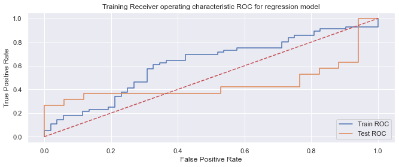

```python
fprtrain, tprtrain, thresholds = roc_curve(ytrain, model.predict(sm.add_constant(xtrain)))
fprtest, tprtest, thresholds = roc_curve(ytest, model.predict(sm.add_constant(xtest)))
plt.figure()
plt.plot(fprtrain, tprtrain, label="Train ROC")
plt.plot(fprtest, tprtest, label='Test ROC')
plt.legend(loc="lower right")
plt.plot([0, 1], [0, 1],'r--')
plt.xlabel('False Positive Rate')
plt.ylabel('True Positive Rate')
plt.title('Training Receiver operating characteristic ROC for regression model')
plt.show()
```

Meanwhile we also have the random forest model with the different estimators score. So we are also going to create the ROC for that.

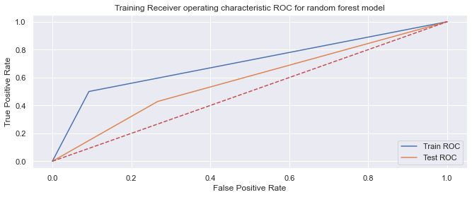

```python
X_Random = df[['negative', 'hospitalizedCurrently' ,'recovered' ,'hospitalized' ,'deathIncrease', 'hospitalizedIncrease']]
y = df['stock_trend']
RFmodel = rfc(n_estimators = 20, max_depth = 2)
X_train, X_test, y_train, y_test = ms.train_test_split(X, y, test_size=0.25, random_state=2)
RFmodel.fit(X_train, y_train)
fprtrain, tprtrain, thresholds = roc_curve(y_train, RFmodel.predict(X_train))
fprtest, tprtest, thresholds = roc_curve(y_test, RFmodel.predict(X_test))
plt.figure()
plt.plot(fprtrain, tprtrain, label="Train ROC")
plt.plot(fprtest, tprtest, label='Test ROC')
plt.legend(loc="lower right")
plt.plot([0, 1], [0, 1],'r--')
plt.xlabel('False Positive Rate')
plt.ylabel('True Positive Rate')
plt.title('Training Receiver operating characteristic ROC for random forest model')
plt.show()
```

### Colored Confusion matrix of the regression model

```python
Rpred = model.predict(sm.add_constant(xtrain)).round(decimals=0)
```

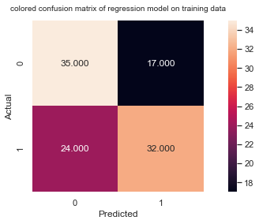

```python
Matrix = cm(ytrain, Rpred)
a = sns.heatmap(Matrix, annot=True, fmt=".3f", square = True);
plt.ylabel('Actual');
plt.xlabel('Predicted');
a.set_title('colored confusion matrix of regression model on training data', fontdict={'fontsize':10}, pad=12)
```

```python
Rpred = model.predict(sm.add_constant(xtest)).round(decimals=0)
```

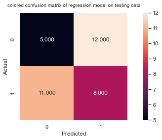

```python
Matrix = cm(ytest, Rpred)
a = sns.heatmap(Matrix, annot=True, fmt=".3f", square = True);
plt.ylabel('Actual');
plt.xlabel('Predicted');
a.set_title('colored confusion matrix of regression model on testing data', fontdict={'fontsize':10}, pad=12)
```

### Coloured Confusion Matrix for the Random forest model

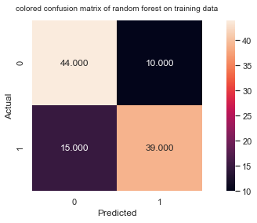

```python
X_Random = df[['negative', 'hospitalizedCurrently' ,'recovered' ,'hospitalized' ,'deathIncrease', 'hospitalizedIncrease']]
y = df['stock_trend']
RFmodel = rfc(n_estimators = 20, max_depth = 2)
X_train, X_test, y_train, y_test = ms.train_test_split(X, y, test_size=0.25, random_state=2)
RFmodel.fit(X_train, y_train)
RFpred = RFmodel.predict(X_train).round(decimals=0)
RFMatrix = cm(y_train, RFpred)
a = sns.heatmap(RFMatrix, annot=True, fmt=".3f", square = True);
plt.ylabel('Actual');
plt.xlabel('Predicted');
a.set_title('colored confusion matrix of random forest on training data', fontdict={'fontsize':10}, pad=12)
plt.show()
```

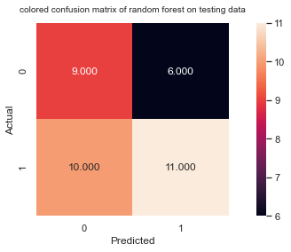

```python
RFpred = RFmodel.predict(X_test).round(decimals=0)
RFMatrix = cm(y_test, RFpred)
a = sns.heatmap(RFMatrix, annot=True, fmt=".3f", square = True);
plt.ylabel('Actual');
plt.xlabel('Predicted');
a.set_title('colored confusion matrix of random forest on testing data', fontdict={'fontsize':10}, pad=12)
plt.show()
```

# Model selection

```python
#Accuracy score for logistic regression testing data
print("Accuracy for regression model:",metrics.accuracy_score(ytest4, testpred4))

#Accuracy score for the random forest testing data
print("Accuracy for random forest model: ", RFmodel.score(X_test, y_test))
```

```
Accuracy for regression model: 0.5344827586206896
Accuracy for random forest model:  0.5555555555555556
```